# Part I - ProsperLoanData

## by Shingirai Alvin Svinurai

## Introduction

This document explores a dataset containing Loan and Borrower attributes for around 114,000 loans.

## Preliminary Wrangling

```python
# import all packages and set plots to be embedded inline
import numpy as np
import pandas as pd
import matplotlib.pyplot as plt
import seaborn as sb

%matplotlib inline
```

```python
#loading pata to a pandas dataframe
loan_df = pd.read_csv("prosperLoanData.csv")
```

Viewing the dataset's properties: shape and descriptive statistics

```python
loan_df.shape
```

```
(113937, 81)
```

```python
loan_df.describe()
```

|  | ListingNumber | Term | BorrowerAPR | BorrowerRate | LenderYield | EstimatedEffectiveYield | EstimatedLoss | EstimatedReturn | ProsperRating (numeric) | ProsperScore | ... | LP_ServiceFees | LP_CollectionFees | LP_GrossPrincipalLoss | LP_NetPrincipalLoss | LP_NonPrincipalRecoverypayments | PercentFunded | Recommendations | InvestmentFromFriendsCount | InvestmentFromFriendsAmount | Investors |
| --- | --- | --- | --- | --- | --- | --- | --- | --- | --- | --- | --- | --- | --- | --- | --- | --- | --- | --- | --- | --- | --- |
| count | 1.139370e+05 | 113937.000000 | 113912.000000 | 113937.000000 | 113937.000000 | 84853.000000 | 84853.000000 | 84853.000000 | 84853.000000 | 84853.000000 | ... | 113937.000000 | 113937.000000 | 113937.000000 | 113937.000000 | 113937.000000 | 113937.000000 | 113937.000000 | 113937.000000 | 113937.000000 | 113937.000000 |
| mean | 6.278857e+05 | 40.830248 | 0.218828 | 0.192764 | 0.182701 | 0.168661 | 0.080306 | 0.096068 | 4.072243 | 5.950067 | ... | -54.725641 | -14.242698 | 700.446342 | 681.420499 | 25.142686 | 0.998584 | 0.048027 | 0.023460 | 16.550751 | 80.475228 |
| std | 3.280762e+05 | 10.436212 | 0.080364 | 0.074818 | 0.074516 | 0.068467 | 0.046764 | 0.030403 | 1.673227 | 2.376501 | ... | 60.675425 | 109.232758 | 2388.513831 | 2357.167068 | 275.657937 | 0.017919 | 0.332353 | 0.232412 | 294.545422 | 103.239020 |
| min | 4.000000e+00 | 12.000000 | 0.006530 | 0.000000 | -0.010000 | -0.182700 | 0.004900 | -0.182700 | 1.000000 | 1.000000 | ... | -664.870000 | -9274.750000 | -94.200000 | -954.550000 | 0.000000 | 0.700000 | 0.000000 | 0.000000 | 0.000000 | 1.000000 |
| 25% | 4.009190e+05 | 36.000000 | 0.156290 | 0.134000 | 0.124200 | 0.115670 | 0.042400 | 0.074080 | 3.000000 | 4.000000 | ... | -73.180000 | 0.000000 | 0.000000 | 0.000000 | 0.000000 | 1.000000 | 0.000000 | 0.000000 | 0.000000 | 2.000000 |
| 50% | 6.005540e+05 | 36.000000 | 0.209760 | 0.184000 | 0.173000 | 0.161500 | 0.072400 | 0.091700 | 4.000000 | 6.000000 | ... | -34.440000 | 0.000000 | 0.000000 | 0.000000 | 0.000000 | 1.000000 | 0.000000 | 0.000000 | 0.000000 | 44.000000 |
| 75% | 8.926340e+05 | 36.000000 | 0.283810 | 0.250000 | 0.240000 | 0.224300 | 0.112000 | 0.116600 | 5.000000 | 8.000000 | ... | -13.920000 | 0.000000 | 0.000000 | 0.000000 | 0.000000 | 1.000000 | 0.000000 | 0.000000 | 0.000000 | 115.000000 |
| max | 1.255725e+06 | 60.000000 | 0.512290 | 0.497500 | 0.492500 | 0.319900 | 0.366000 | 0.283700 | 7.000000 | 11.000000 | ... | 32.060000 | 0.000000 | 25000.000000 | 25000.000000 | 21117.900000 | 1.012500 | 39.000000 | 33.000000 | 25000.000000 | 1189.000000 |

8 rows × 61 columns

```python
loan_df.info()
```

```
<class 'pandas.core.frame.DataFrame'>
RangeIndex: 113937 entries, 0 to 113936
Data columns (total 81 columns):
 #   Column                               Non-Null Count   Dtype
---  ------                               --------------   -----
 0   ListingKey                           113937 non-null  object
 1   ListingNumber                        113937 non-null  int64
 2   ListingCreationDate                  113937 non-null  object
 3   CreditGrade                          28953 non-null   object
 4   Term                                 113937 non-null  int64
 5   LoanStatus                           113937 non-null  object
 6   ClosedDate                           55089 non-null   object
 7   BorrowerAPR                          113912 non-null  float64
 8   BorrowerRate                         113937 non-null  float64
 9   LenderYield                          113937 non-null  float64
```

[output cut: 73 more lines]

Vissually inspect dataset

```python
loan_df.sample(10)
```

|  | ListingKey | ListingNumber | ListingCreationDate | CreditGrade | Term | LoanStatus | ClosedDate | BorrowerAPR | BorrowerRate | LenderYield | ... | LP_ServiceFees | LP_CollectionFees | LP_GrossPrincipalLoss | LP_NetPrincipalLoss | LP_NonPrincipalRecoverypayments | PercentFunded | Recommendations | InvestmentFromFriendsCount | InvestmentFromFriendsAmount | Investors |
| --- | --- | --- | --- | --- | --- | --- | --- | --- | --- | --- | --- | --- | --- | --- | --- | --- | --- | --- | --- | --- | --- |
| 37088 | 3A6635250772035878CC4C5 | 524914 | 2011-09-01 09:32:38.197000000 | NaN | 36 | Completed | 2012-08-30 00:00:00 | 0.12400 | 0.1029 | 0.0929 | ... | -16.99 | 0.0 | 0.00 | 0.00 | 0.00 | 1.0 | 0 | 0 | 0.0 | 39 |
| 89781 | F7693539924137494A69587 | 563716 | 2012-02-28 14:05:33.253000000 | NaN | 36 | Completed | 2013-09-11 00:00:00 | 0.35797 | 0.3177 | 0.3077 | ... | -49.61 | 0.0 | 0.00 | 0.00 | 0.00 | 1.0 | 0 | 0 | 0.0 | 10 |
| 24484 | 12C53590359685839F67EC7 | 924160 | 2013-09-27 03:49:01.827000000 | NaN | 36 | Current | NaN | 0.20626 | 0.1695 | 0.1595 | ... | -32.60 | 0.0 | 0.00 | 0.00 | 0.00 | 1.0 | 0 | 0 | 0.0 | 1 |
| 90379 | A5F634165668624903B754F | 293126 | 2008-03-13 21:27:30.813000000 | AA | 36 | Completed | 2011-03-08 00:00:00 | 0.08182 | 0.0750 | 0.0750 | ... | 0.00 | 0.0 | 0.00 | 0.00 | 0.00 | 1.0 | 0 | 0 | 0.0 | 52 |
| 66488 | 36F834863127193153A9A2B | 462307 | 2010-06-12 18:49:22.053000000 | NaN | 36 | Completed | 2013-06-23 00:00:00 | 0.07469 | 0.0713 | 0.0613 | ... | -15.95 | 0.0 | 0.00 | 0.00 | 0.00 | 1.0 | 0 | 0 | 0.0 | 20 |
| 105941 | BEFB35252501633160192D3 | 525660 | 2011-09-04 12:31:03.013000000 | NaN | 36 | Completed | 2013-07-29 00:00:00 | 0.22362 | 0.1899 | 0.1799 | ... | -70.36 | 0.0 | 0.00 | 0.00 | 0.00 | 1.0 | 0 | 0 | 0.0 | 74 |
| 88991 | 22E83514351629692C94980 | 505773 | 2011-05-07 19:00:51.487000000 | NaN | 36 | Completed | 2013-03-11 00:00:00 | 0.35643 | 0.3199 | 0.3099 | ... | -28.94 | 0.0 | 0.00 | 0.00 | 0.00 | 1.0 | 0 | 0 | 0.0 | 17 |
| 71923 | 8B3D35960609412367F79AA | 1070039 | 2013-12-13 08:19:44.697000000 | NaN | 36 | Current | NaN | 0.17611 | 0.1400 | 0.1300 | ... | -41.99 | 0.0 | 0.00 | 0.00 | 0.00 | 1.0 | 0 | 0 | 0.0 | 1 |
| 105955 | 1219358372275532512E20A | 849139 | 2013-07-23 13:25:03.953000000 | NaN | 60 | Current | NaN | 0.28386 | 0.2579 | 0.2479 | ... | -73.61 | 0.0 | 0.00 | 0.00 | 0.00 | 1.0 | 0 | 0 | 0.0 | 32 |
| 104420 | 863D3391821097536040751 | 147542 | 2007-06-06 07:18:48.230000000 | C | 36 | Chargedoff | 2008-03-12 00:00:00 | 0.21448 | 0.2071 | 0.1871 | ... | -13.59 | 0.0 | 3281.09 | 3281.08 | 116.34 | 1.0 | 0 | 0 | 0.0 | 45 |

10 rows × 81 columns

1. The following 5 date columns: ListingCreationDate, ClosedDate, DateCreditPulled, FirstRecordedCreditLine, LoanOriginationDate are of incorrect data types.
2. ListingNumber, LoanNumber are Key/ID columns classified as float/int(no claculation will be perfomed on these).
3. Several categorical columns classified as "objects".
4. The dataset contains attributes on 3 objects, Listing, Loan and Borrower details. However we will select specific columns that will be of interest for our investigation.

Create a copy for editing and preserve the original dataframe

```python
loan_df_edit = pd.read_csv("prosperLoanData.csv").copy(deep=True)
```

Change columns to datetime data type

```python
date_columns = ["ListingCreationDate", "ClosedDate", "DateCreditPulled", "FirstRecordedCreditLine", "LoanOriginationDate"]
for column in date_columns:
    loan_df_edit[column] = pd.to_datetime(loan_df_edit[column])
```

Change id columns to "object" datatype

```python
id_columns = ["ListingNumber", "LoanNumber"]
for column in id_columns:
    loan_df_edit[column] = loan_df_edit[column].astype(str)
```

Fill N/A in EmploymentStatus with "Not available" since that the default for missing data for this column

```python
loan_df_edit.fillna({'EmploymentStatus':"Not available"}, inplace=True)
```

Create subset of data with columns of interest.

```python
loanDataSubset = loan_df_edit[["Term", "LoanStatus", "BorrowerAPR", "ListingCategory (numeric)", "Occupation",
                               "EmploymentStatus", "DebtToIncomeRatio", "IncomeRange",
                               "StatedMonthlyIncome", "LoanOriginalAmount", "LoanOriginationDate", "MonthlyLoanPayment"
                          ]].copy(deep=True)
```

```python
loanDataSubset.info()
```

```
<class 'pandas.core.frame.DataFrame'>
RangeIndex: 113937 entries, 0 to 113936
Data columns (total 12 columns):
 #   Column                     Non-Null Count   Dtype
---  ------                     --------------   -----
 0   Term                       113937 non-null  int64
 1   LoanStatus                 113937 non-null  object
 2   BorrowerAPR                113912 non-null  float64
 3   ListingCategory (numeric)  113937 non-null  int64
 4   Occupation                 110349 non-null  object
 5   EmploymentStatus           113937 non-null  object
 6   DebtToIncomeRatio          105383 non-null  float64
 7   IncomeRange                113937 non-null  object
 8   StatedMonthlyIncome        113937 non-null  float64
 9   LoanOriginalAmount         113937 non-null  int64
 10  LoanOriginationDate        113937 non-null  datetime64[ns]
 11  MonthlyLoanPayment         113937 non-null  float64
dtypes: datetime64[ns](1), float64(4), int64(3), object(4)
memory usage: 10.4+ MB
```

There are several sub-level for students and tradesman with the occupation category. We will use split to combine these.

```python
def convertOccupation(name):
    try:
        return name.split('-')[0]
    except AttributeError as error:
        return name
```

```python
loanDataSubset["Occupation"] = loanDataSubset["Occupation"].apply(convertOccupation)
```

```python
loanDataSubset["Occupation"].unique()
```

```
array(['Other', 'Professional', 'Skilled Labor', 'Executive', 'Sales ',
       'Laborer', 'Food Service', 'Fireman', 'Waiter/Waitress',
       'Construction', 'Computer Programmer', 'Retail Management',
       'Engineer ', 'Military Enlisted', 'Clerical', nan, 'Teacher',
       'Clergy', 'Accountant/CPA', 'Attorney', 'Nurse (RN)', 'Analyst',
       "Nurse's Aide", 'Investor', 'Realtor', 'Flight Attendant',
       'Nurse (LPN)', 'Military Officer', 'Food Service Management',
       'Truck Driver', 'Administrative Assistant',
       'Police Officer/Correction Officer', 'Social Worker', 'Tradesman ',
       'Medical Technician', 'Professor', 'Postal Service',
       'Civil Service', 'Pharmacist', 'Scientist', 'Dentist', 'Architect',
       'Landscaping', 'Bus Driver', 'Doctor', 'Chemist', 'Student ',
       'Principal', "Teacher's Aide", 'Pilot ', 'Religious', 'Homemaker',
       'Psychologist', 'Biologist', 'Judge', 'Car Dealer'], dtype=object)
```

```python
loanDataSubset.isna().any()
```

```
Term                         False
LoanStatus                   False
BorrowerAPR                   True
ListingCategory (numeric)    False
Occupation                    True
EmploymentStatus             False
DebtToIncomeRatio             True
IncomeRange                  False
StatedMonthlyIncome          False
LoanOriginalAmount           False
LoanOriginationDate          False
MonthlyLoanPayment           False
dtype: bool
```

The dataset contain empty values, will proceed to investigate their effect

Change Categorical columns to categorical datatypes, EmploymentStatus, IncomeRange(ordered)

```python
EmploymentStatus_categories = pd.api.types.CategoricalDtype(loanDataSubset['EmploymentStatus'].unique())
loanDataSubset['EmploymentStatus'] = loanDataSubset['EmploymentStatus'].astype(EmploymentStatus_categories)
```

```python
IncomeRanges = ['Not employed', 'Not displayed', '$0',
                '$1-24,999', '$25,000-49,999', '$50,000-74,999',
                '$75,000-99,999', '$100,000+']
IncomeRanges_categories = pd.api.types.CategoricalDtype(IncomeRanges, ordered=True)
loanDataSubset['IncomeRange'] = loanDataSubset['IncomeRange'].astype(IncomeRanges_categories)
loanDataSubset['IncomeRange'].dtype
```

```
CategoricalDtype(categories=['Not employed', 'Not displayed', '$0', '$1-24,999',
                  '$25,000-49,999', '$50,000-74,999', '$75,000-99,999',
                  '$100,000+'],
, ordered=True)
```

```python
LoanStatus = ['Cancelled', 'Defaulted', 'Chargedoff', 'Completed', 'FinalPaymentInProgress', 'Current', 'Past Due (1-15 days)',
                   'Past Due (16-30 days)', 'Past Due (61-90 days)', 'Past Due (31-60 days)',
                  'Past Due (91-120 days)', 'Past Due (>120 days)']
LoanStatus_categories = pd.api.types.CategoricalDtype(LoanStatus)
loanDataSubset['LoanStatus'] = loanDataSubset['LoanStatus'].astype(LoanStatus_categories)
loanDataSubset['LoanStatus'].dtype
```

```
CategoricalDtype(categories=['Cancelled', 'Defaulted', 'Chargedoff', 'Completed',
                  'FinalPaymentInProgress', 'Current', 'Past Due (1-15 days)',
                  'Past Due (16-30 days)', 'Past Due (61-90 days)',
                  'Past Due (31-60 days)', 'Past Due (91-120 days)',
                  'Past Due (>120 days)'],
, ordered=False)
```

```python
loanDataSubset.rename({"ListingCategory (numeric)":"ListingCategory"}, inplace=True, axis=1)
```

```python
loanDataSubset.columns
```

```
Index(['Term', 'LoanStatus', 'BorrowerAPR', 'ListingCategory', 'Occupation',
       'EmploymentStatus', 'DebtToIncomeRatio', 'IncomeRange',
       'StatedMonthlyIncome', 'LoanOriginalAmount', 'LoanOriginationDate',
       'MonthlyLoanPayment'],
      dtype='object')
```

```python
ListingCategory = pd.api.types.CategoricalDtype(loanDataSubset["ListingCategory"].unique())
loanDataSubset["ListingCategory (numeric)"] = loanDataSubset["ListingCategory"].astype(ListingCategory)
```

```python
loanDataSubset.info()
```

```
<class 'pandas.core.frame.DataFrame'>
RangeIndex: 113937 entries, 0 to 113936
Data columns (total 13 columns):
 #   Column                     Non-Null Count   Dtype
---  ------                     --------------   -----
 0   Term                       113937 non-null  int64
 1   LoanStatus                 113937 non-null  category
 2   BorrowerAPR                113912 non-null  float64
 3   ListingCategory            113937 non-null  int64
 4   Occupation                 110349 non-null  object
 5   EmploymentStatus           113937 non-null  category
 6   DebtToIncomeRatio          105383 non-null  float64
 7   IncomeRange                113937 non-null  category
 8   StatedMonthlyIncome        113937 non-null  float64
 9   LoanOriginalAmount         113937 non-null  int64
 10  LoanOriginationDate        113937 non-null  datetime64[ns]
 11  MonthlyLoanPayment         113937 non-null  float64
 12  ListingCategory (numeric)  113937 non-null  category
dtypes: category(4), datetime64[ns](1), float64(4), int64(3), object(1)
memory usage: 8.3+ MB
```

```python
loanDataSubset.isna().sum()
```

```
Term                            0
LoanStatus                      0
BorrowerAPR                    25
ListingCategory                 0
Occupation                   3588
EmploymentStatus                0
DebtToIncomeRatio            8554
IncomeRange                     0
StatedMonthlyIncome             0
LoanOriginalAmount              0
LoanOriginationDate             0
MonthlyLoanPayment              0
ListingCategory (numeric)       0
dtype: int64
```

### What is the structure of your dataset?

The dataset comprises data on 113937 loans with 81 attributes corresponding to the loan, borrower and lender's details. 61 columns are numeric including the key/id columns and categorical types for ListingCategory. The columns include, amoung others; BorrowerRate, EmploymentStatus, IncomeRange, LoanOriginalAmount.

### What is/are the main feature(s) of interest in your dataset?

I am most interested in features that determain a loan’s outcome status?

### What features in the dataset do you think will help support your investigation into your feature(s) of interest?

I suspect a borrower's ability to pay back a loan is greatly affected by their "DebtToIncomeRatio", the lower the ratio, the more finance available to repay a loan. I suspect other variables associated with debt and income, though not to as much an extent, will also affect the borrower's ability to repay. Attributes like BorrowerAPR, ListingCategory, EmploymentStatus and IncomeRange

## Univariate Exploration

We start by looking at the distribution of the outcome variable: LoanStatus.

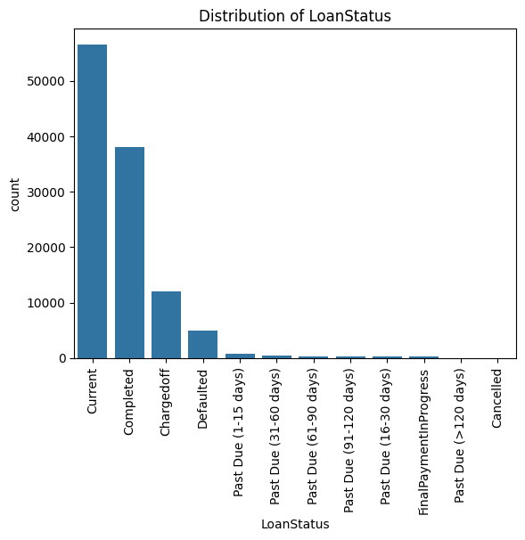

```python
base_color = sb.color_palette()[0]
order = loanDataSubset['LoanStatus'].value_counts().index
sb.countplot(data=loanDataSubset, x='LoanStatus', color=base_color, order=order)
plt.title("Distribution of LoanStatus")
plt.xticks(rotation=90);
```

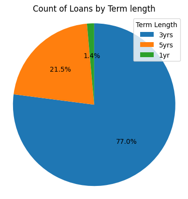

```python
# Use the same pokemon dataset
sorted_counts = loanDataSubset['Term'].value_counts()
plt.pie(sorted_counts, autopct='%1.1f%%', startangle = 90, counterclock = False)
plt.legend(title='Term Length', labels = ['3yrs', '5yrs', '1yr'])
plt.title("Count of Loans by Term length")
plt.axis('square');
```

It appears loans in this dataset have a term length of 1, 3 and 5years. It is amaizing how dispite the dataset spanning twice the period of the longest term loan, Current loans has the highest freaquency. It must be loan listing is increasing each year.

```python
def date_to_year(datetime_object):
    return datetime_object.year
```

```python
#Create a columns with start year for each loan
loanDataSubset['LoanComencementYear'] = loanDataSubset['LoanOriginationDate'].apply(date_to_year)
```

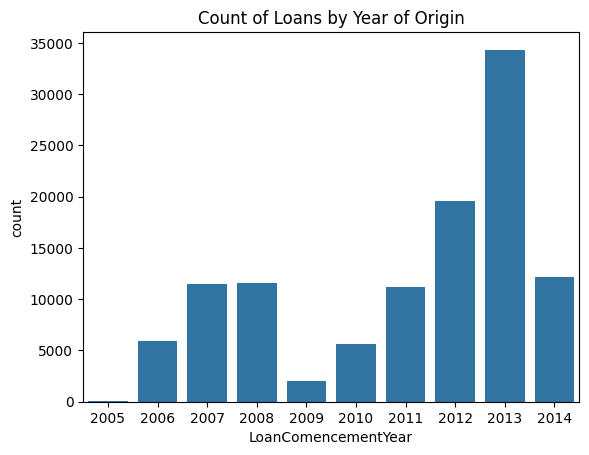

```python
sb.countplot(data=loanDataSubset, x='LoanComencementYear', color=base_color)
plt.title("Count of Loans by Year of Origin");
```

As suspected, there is an upward trend in the data. The first before 2008, and a sharp drop for 2009, consistanmt with the global depression of 2008, and the second upward trend from 2009 going forward. The trend for 2005 and 2014 is consistant as there are only 2 and 3 months for the respectives years in the dataset. The majority of the loans originated in the last 3 years of the dataset, with 2013 having the highest count and 2012 in second place.

Secondly we look into the distribution of Income levels.

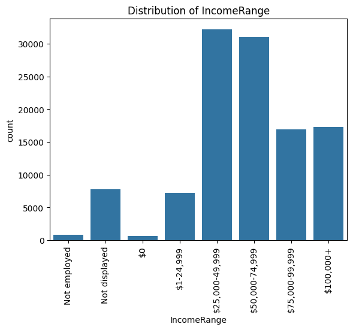

```python
base_color = sb.color_palette()[0]
sb.countplot(data=loanDataSubset, x='IncomeRange', color=base_color)
plt.title("Distribution of IncomeRange")
plt.xticks(rotation=90);
```

Our dataset contains loans for which no income data is available. We will proceed further to take a snapshot of loans for with income data was provided.

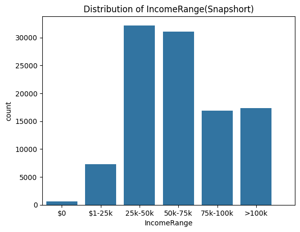

```python
base_color = sb.color_palette()[0]
sb.countplot(data=loanDataSubset, x='IncomeRange', color=base_color)
plt.title("Distribution of IncomeRange(Snapshort)")
plt.xlim([1.5, 8])
plt.xticks([2, 3, 4, 5, 6, 7], ['$0', '$1-25k', '25k-50k', '50k-75k', '75k-100k', '>100k']);
```

The majority of the incomes lie above the \$50,000 mark. We will take a deep dive into the loan member declared incomes. Loan were given to people without income.

```python
def income_distribution(binsize):
    bins = np.arange(loanDataSubset['StatedMonthlyIncome'].min(), loanDataSubset['StatedMonthlyIncome'].max()+binsize, binsize)
    plt.hist(data=loanDataSubset, x="StatedMonthlyIncome", bins=bins)
    locs, ticks = plt.xticks()
    plt.title('Distribution of StatedMonthlyIncome')
    plt.xlabel('StatedMonthlyIncome ($)')
    plt.xticks(locs, ['','$0', "250k", '500k', '750k', '1M', '1.25M', '1.5M', '1.75M', '2M'])
```

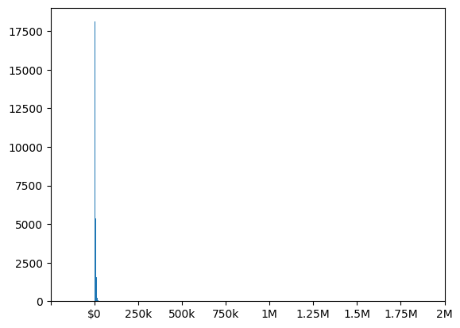

```python
binsize = 1000
income_distribution(binsize)
```

The points appear clustered about 0. There appears to be outliers affecting the distribution.

Taken from: [Format a number with commas to separate thousands](https://stackoverflow.com/questions/43102734/format-a-number-with-commas-to-separate-thousands)

```python
loanDataSubset[['StatedMonthlyIncome']].describe().style.format({"StatedMonthlyIncome": "{:,.0f}"})
```

|  | StatedMonthlyIncome |
| --- | --- |
| count | 113,937 |
| mean | 5,608 |
| std | 7,478 |
| min | 0 |
| 25% | 3,200 |
| 50% | 4,667 |
| 75% | 6,825 |
| max | 1,750,003 |

```python
#check loans above $100,000
loanDataSubset.query('StatedMonthlyIncome > 100000' )[['IncomeRange', 'StatedMonthlyIncome']].style.format({"StatedMonthlyIncome": "{:,.0f}"})
```

|  | IncomeRange | StatedMonthlyIncome |
| --- | --- | --- |
| 8066 | $100,000+ | 416,667 |
| 8870 | Not displayed | 208,333 |
| 17411 | $100,000+ | 483,333 |
| 35218 | $100,000+ | 108,333 |
| 45028 | $100,000+ | 150,000 |
| 53014 | $100,000+ | 618,548 |
| 53167 | $100,000+ | 1,750,003 |
| 56867 | $100,000+ | 185,082 |
| 57133 | $100,000+ | 466,667 |
| 59298 | $100,000+ | 120,833 |
| 63925 | Not displayed | 140,417 |
| 78431 | $100,000+ | 103,334 |
| 80075 | $100,000+ | 158,333 |
| 82831 | $100,000+ | 250,000 |
| 83697 | Not displayed | 185,082 |
| 111265 | $100,000+ | 108,750 |
| 113270 | $100,000+ | 394,400 |

There are only 17 values above \$100,000 with the biggest outlier at \$1,750,003. Removing outliers, all values above \$20000, about 1% of the data we get the following plot.

```python
loanDataSubset = loanDataSubset[loanDataSubset.StatedMonthlyIncome <=20000]
```

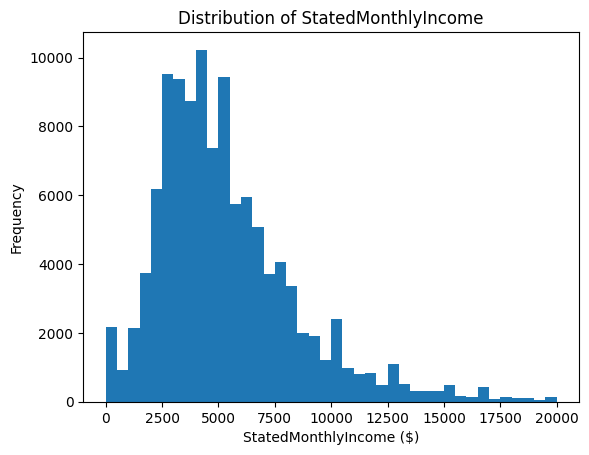

```python
binsize = 500
income_distribution(binsize);
```

The distribution of StatedMonthlyIncome appears to unimodal with the highest pick around \$4,000 and it appears to tail-of to the right from about \$6,000

We will look at the distribution of the cost of the loan to the borrower.

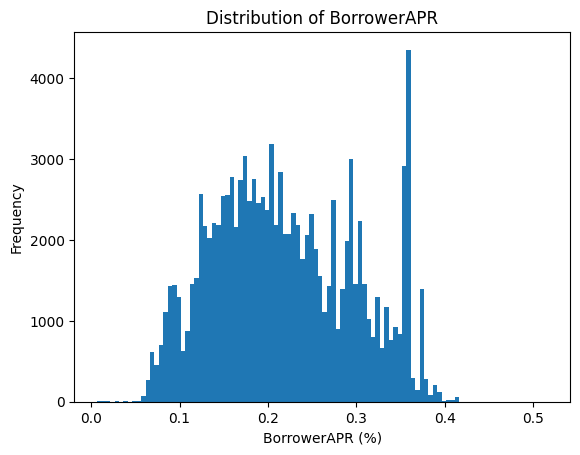

```python
binsize = 0.005
bins = np.arange(loanDataSubset['BorrowerAPR'].min(), loanDataSubset['BorrowerAPR'].max()+binsize, binsize)
plt.hist(data=loanDataSubset, x="BorrowerAPR", bins=bins)
plt.xlabel('BorrowerAPR (%)')
plt.ylabel('Frequency')
plt.title('Distribution of BorrowerAPR');
```

Futhermore, we look into the distribution of the base loan amount.

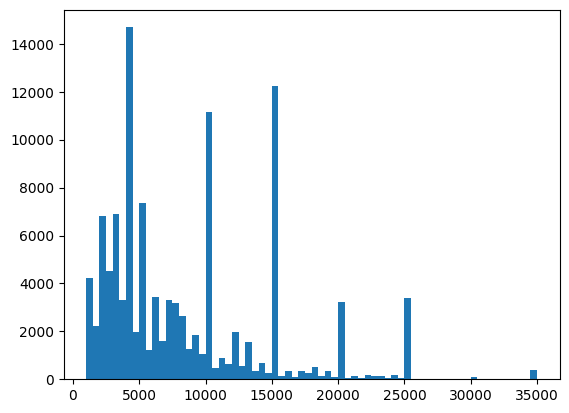

```python
binsize=500
bins=np.arange(min(loanDataSubset['LoanOriginalAmount']), max(loanDataSubset['LoanOriginalAmount'])+binsize, binsize)
plt.hist(data=loanDataSubset, x='LoanOriginalAmount', bins=bins);
```

The majority of the loans are of below \$10,000 in value and the appear to peak, in somewhat of a decreaasing sequence, at multiples of 5000, at 5k, 10k, 15k, 20k and 25k with very few loans above \$25,000. The nature of the distribution is quite similar to that of StatedMonthlyIncome, we suspect a positive corrolation between the 2 variable.

Now, we look into whether there occupation more likely to solicty a Loan

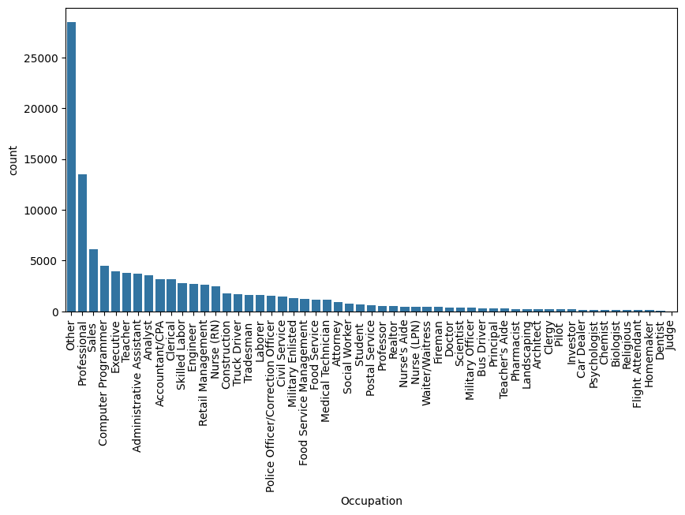

```python
plt.figure(figsize=[10,5])
values = loanDataSubset['Occupation'].value_counts()
sb.countplot(data=loanDataSubset, x='Occupation', color=base_color, order=values.index)
plt.xticks(rotation=90);
```

Amoung those that provided their occupation, the top five occupations are Professional, Sales, Computer Programmer, Executive and Teacher.

Now we move on to investigate the major reasons for which a loan was soliciteted.

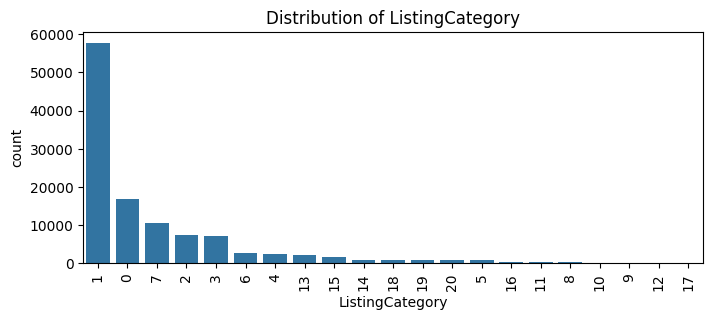

```python
plt.figure(figsize=[8,3])

base_color = sb.color_palette()[0]
order = loanDataSubset['ListingCategory'].value_counts()
sb.countplot(data=loanDataSubset, x='ListingCategory', order=order.index, color=base_color)
plt.title("Distribution of ListingCategory")
plt.xticks(rotation=90);
```

The most popular list category is category 1:Debt Consolidation.

### Of the features you investigated, were there any unusual distributions? Did you perform any operations on the data to tidy, adjust, or change the form of the data? If so, why did you do this?

LoanStatus, IncomeRange and EmploymentStatus datatype was changed to "Categorical" and LoanOriginationDate was converted to a datetime object. An additional column was created so as to group loans by "LoanOriginationYear".

## Bivariate Exploration

We noted an infered relationship between LoanStatus and LoanComencementYear in the previous section, we would like to further investigate the relationship.

```python
statusYear_counts = loanDataSubset.groupby(["LoanStatus", "LoanComencementYear"]).size()
```

```python
statusYear_counts = statusYear_counts.reset_index(name='count')
```

```python
statusYear_counts = statusYear_counts.pivot(index = 'LoanStatus', columns = 'LoanComencementYear', values = 'count')
```

Taken from: [How to add a label to Seaborn Heatmap color bar?](https://stackoverflow.com/questions/42092218/how-to-add-a-label-to-seaborn-heatmap-color-bar)

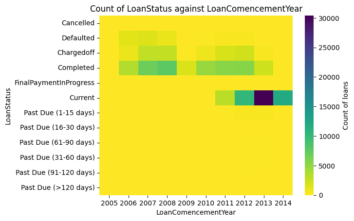

```python
sb.heatmap(statusYear_counts, cmap='viridis_r',  cbar_kws={'label': 'Count of loans'})
plt.title('Count of LoanStatus against LoanComencementYear');
```

We further assess LoanStatus against additional categorical variables

```python
#categorical variables in dataset
variables = ["EmploymentStatus", "IncomeRange", "Term"]
```

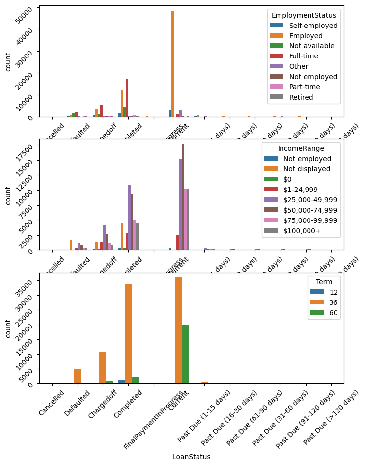

```python
fig, ax = plt.subplots(nrows=3, figsize = [8, 10])
for i in range(len(variables)):
    var = variables[i]
    sb.countplot(data = loanDataSubset, x = "LoanStatus", hue = var, ax=ax[i])
    ax[i].tick_params(labelrotation=45);
```

On average, Employed and Fulltime are the most visible "EmploymentStatus" level accross all level of LoanStatus. We also notice the highest counts are shared between the "25k-50k" and "50k-75k" income ranges accross level of LoanStatus. The 36months Term length has the highest count with 60 months having the second highest count. This is consistant with our ealier discovery, 77% and 22% of the data fall in the 36 and 60 months Term respectively

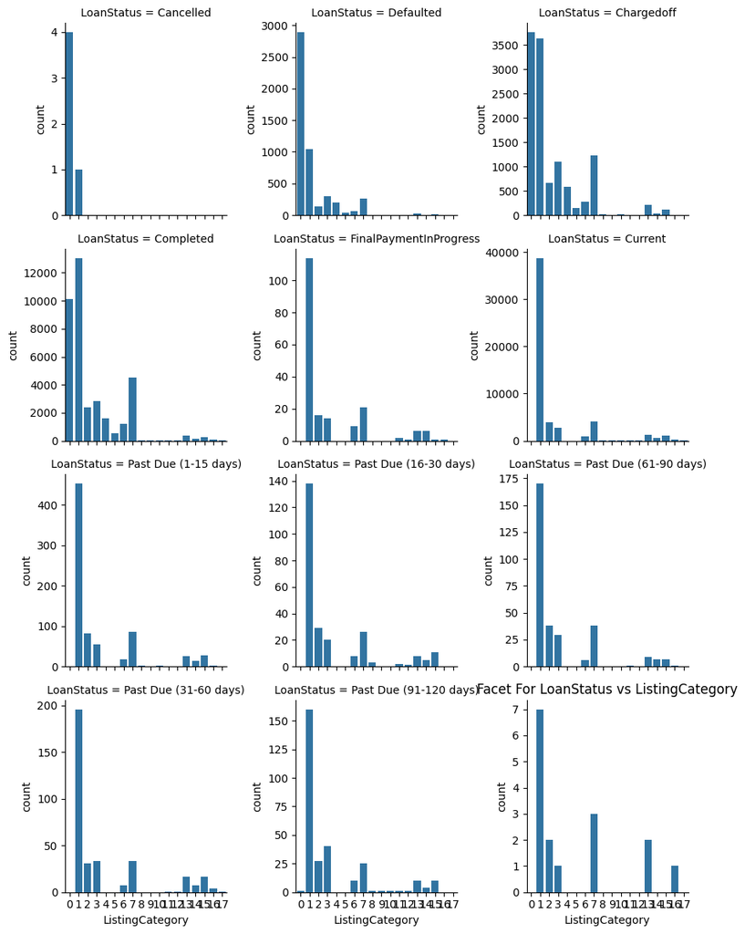

```python
g = sb.FacetGrid(data = loanDataSubset, col = 'LoanStatus', col_wrap=3, sharey=False)
g.map(sb.countplot, "ListingCategory", order=np.arange(0,18,1))
#g.set_xticklabels(rotation=45)
plt.title("Facet For LoanStatus vs ListingCategory");
```

Next we investigate the relationship between our variable of interest, LoanStatus and numeric variables within the dataset.

```python
variables = ["BorrowerAPR", "DebtToIncomeRatio", "StatedMonthlyIncome", "LoanOriginalAmount", "MonthlyLoanPayment"]
```

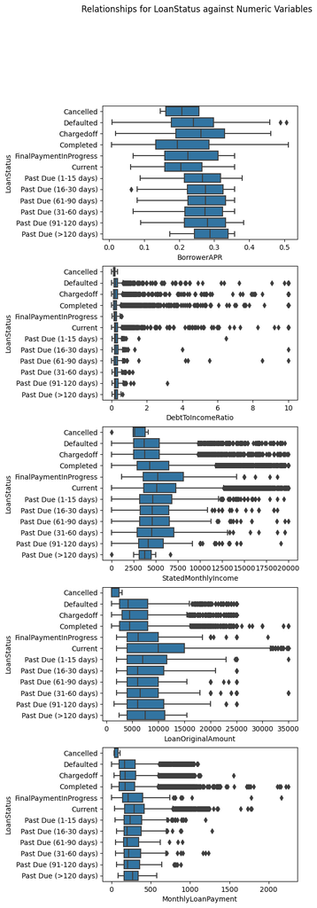

```python
fig, ax = plt.subplots(nrows=5, figsize = [5, 20])
for i in range(len(variables)):
    var = variables[i]
    sb.boxplot(data=loanDataSubset, y='LoanStatus', x=var, color=base_color, ax=ax[i])

plt.suptitle("Relationships for LoanStatus against Numeric Variables");
```

From the first plot, it can be seen the higher the mean BorrowerAPR, the higher the chances the loan is in an unfavourable status. LoanPast Due >120 days has the highest BorrowerAPR, and the categories appear in a near decreasing sequence of days down to "Past Due (1-15 days)". Compeleted category has the least BorrowerAPR, and Current and FinalPaymentsInProgress are among the categories with the least BorrowerAPR.

All LoanStatus categories have the median DebtToIncomeRation abount 0, with the highest points of outliers on Completed category.

The highest stated salaries tend to be in the "Current" and FinalPaymentsInProgress categories. On one end, the highest median LoanOriginalAmounts are in the "Current" category with the second highest being in the "120 days Past Due" category. Loans with the highest median MonthlyLoanPayment are in the "Current"status.

in the next plot, we investigate the relationship between the numeric variables in the dataset.

We start with investigating the 3 variables: MonthlyLoanPayment, LoanOriginalAmounts and StatedMonthlyIncome

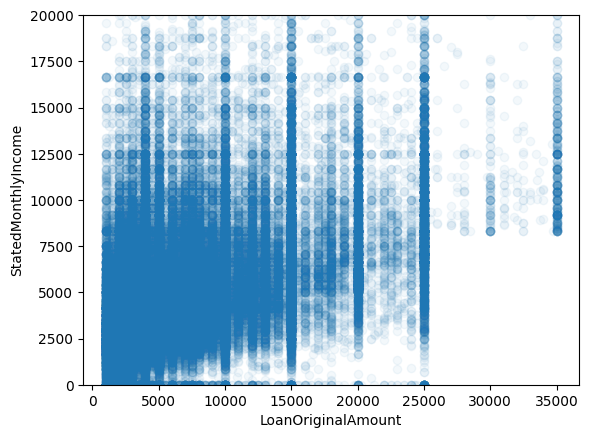

```python
sb.regplot(data=loanDataSubset, x='LoanOriginalAmount', y='StatedMonthlyIncome',
           x_jitter=0.04, fit_reg=False, scatter_kws = {'alpha':0.05})
plt.ylim([0, 20000]);
```

There is a floor Income amount for loans above \$25,000. The majority of th Loan listing are in the range below \$15,000 loan amount and \$7,500 income amount.

we expect there must be a corrolation between the LoanAmount and the monthly payments.

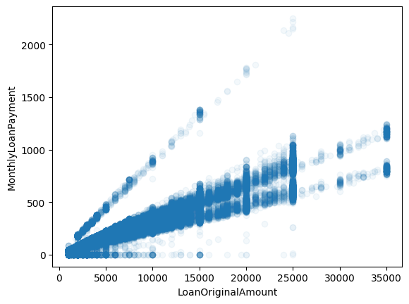

```python
sb.regplot(data=loanDataSubset, x='LoanOriginalAmount', y='MonthlyLoanPayment',
           x_jitter=0.04, fit_reg=False, scatter_kws = {'alpha':0.05});
```

As one would suspect, there is a positive correlation between LoanOriginalAmount and MonthlyLoanPayments

Does term leng affect repayment amounts?

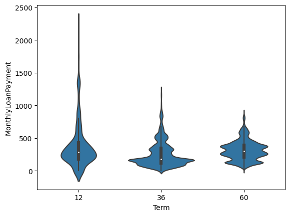

```python
sb.violinplot(data=loanDataSubset, x='Term', y='MonthlyLoanPayment', color=base_color);
```

We calculate the correlation coefficient for each of the numeric variables.

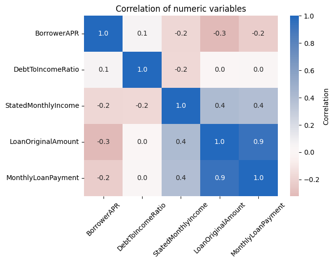

```python
sb.heatmap(loanDataSubset[variables].corr(), annot = True, fmt = '0.1f',
          cmap = 'vlag_r', center = 0, cbar_kws={'label': 'Correlation'})
plt.title("Correlation of numeric variables")
plt.xticks(rotation = 45);
```

DebtToIncomeRatio and StatedMonthlyIncome are negatively ocrrelated, i.e the higher your income, the higher your chances of paying back the debt. Also BorrowerAPR is negatively correlated to LoanOriginalAmount and MonthltLoanPayments. This makes sence since BorrowerAPR is a ratio of LoanOriginalAmount, the higher the denominator, the lower the ratio.

The majority of the loans listed were of below \$15,000 for Monthly incomes of below \$7,500. After \$15,000 a divide begin to form, with higher incomes accessing higher loan amounts. No loans of above \$25,000 were issued for Incomes below \$7,500.

### Did you observe any interesting relationships between the other features (not the main feature(s) of interest)?

The higher the income, the higher the loan one gets. DebtToIncomeRatio and StatedMonthlyIncome are negatively ocrrelated, i.e the higher your income, the higher your chances of paying back the debt. There appear to be a relationship between StatedMonthlyIncome, OriginalLoanAmount and MonthlyLoanPayment, with the highest of all 3 tending to be in the "Current" status.

## Multivariate Exploration

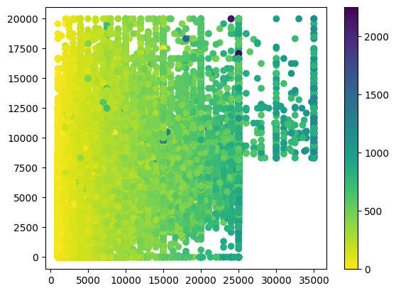

```python
plt.scatter(data = loanDataSubset, x='LoanOriginalAmount',
            y='StatedMonthlyIncome', c='MonthlyLoanPayment', cmap='viridis_r')
plt.colorbar();
#title='Monthly Payments'
```

The relationship is as expected. Higher income levels have access to larger loans and thus will tend to make higher repayments towards their loans. However there are 3 points of inmterest around \$17,500 for both income and loan amount. These appear to be high income individuals making above average loanRepayments. Looking into term length for these loans may provide more information on these

```python
grt_15k = loanDataSubset.query("LoanOriginalAmount>15000 & MonthlyLoanPayment >1500")
grt_15k
```

|  | Term | LoanStatus | BorrowerAPR | ListingCategory | Occupation | EmploymentStatus | DebtToIncomeRatio | IncomeRange | StatedMonthlyIncome | LoanOriginalAmount | LoanOriginationDate | MonthlyLoanPayment | ListingCategory (numeric) | LoanComencementYear |
| --- | --- | --- | --- | --- | --- | --- | --- | --- | --- | --- | --- | --- | --- | --- |
| 8572 | 12 | Completed | 0.17493 | 1 | Construction | Employed | 0.39 | $100,000+ | 10333.333333 | 25000 | 2012-08-31 | 2218.53 | 1 | 2012 |
| 14493 | 12 | FinalPaymentInProgress | 0.17878 | 1 | Laborer | Employed | 0.53 | $50,000-74,999 | 5000.000000 | 20000 | 2013-03-11 | 1778.38 | 1 | 2013 |
| 17504 | 12 | Completed | 0.07090 | 2 | Attorney | Employed | 0.17 | $100,000+ | 19166.666667 | 25000 | 2013-01-28 | 2153.38 | 2 | 2013 |
| 19907 | 12 | Completed | 0.11731 | 1 | Professional | Employed | 0.31 | $100,000+ | 12583.333333 | 20000 | 2013-01-08 | 1739.86 | 1 | 2013 |
| 20533 | 12 | Current | 0.18192 | 1 | Investor | Employed | 0.47 | $75,000-99,999 | 6416.666667 | 20000 | 2013-03-27 | 1781.28 | 1 | 2013 |
| 29025 | 12 | Current | 0.11066 | 1 | Other | Employed | 0.27 | $100,000+ | 15000.000000 | 18988 | 2013-03-22 | 1646.00 | 1 | 2013 |
| 49134 | 12 | Completed | 0.13204 | 1 | Other | Employed | 0.17 | $100,000+ | 16500.000000 | 20000 | 2012-12-05 | 1753.39 | 1 | 2012 |
| 55456 | 12 | Current | 0.16803 | 2 | Nurse (RN) | Employed | 0.35 | $100,000+ | 8333.333333 | 20000 | 2013-04-15 | 1768.47 | 2 | 2013 |
| 58393 | 12 | Completed | 0.07090 | 1 | Professional | Employed | 0.32 | $100,000+ | 10750.000000 | 21000 | 2013-02-07 | 1808.84 | 1 | 2013 |
| 58766 | 12 | FinalPaymentInProgress | 0.07982 | 7 | Architect | Employed | 0.18 | $100,000+ | 13000.000000 | 25000 | 2013-03-08 | 2163.63 | 7 | 2013 |
| 64264 | 12 | Completed | 0.16803 | 1 | Other | Employed | 0.23 | $100,000+ | 11041.666667 | 20000 | 2013-03-25 | 1768.47 | 1 | 2013 |
| 74095 | 12 | Completed | 0.06589 | 1 | Professional | Employed | 0.19 | $100,000+ | 12500.000000 | 20000 | 2012-10-02 | 1718.11 | 1 | 2012 |
| 76075 | 12 | Current | 0.11066 | 1 | Executive | Employed | 0.34 | $100,000+ | 8333.333333 | 20000 | 2013-03-20 | 1733.76 | 1 | 2013 |
| 76785 | 12 | Completed | 0.09986 | 7 | Computer Programmer | Employed | 0.30 | $75,000-99,999 | 7291.666667 | 24500 | 2012-05-10 | 2111.78 | 7 | 2012 |
| 96268 | 12 | Completed | 0.17878 | 2 | Professional | Employed | 0.11 | $100,000+ | 20000.000000 | 24000 | 2012-07-31 | 2134.06 | 2 | 2012 |
| 108949 | 12 | Completed | 0.11409 | 3 | Doctor | Full-time | 0.09 | $100,000+ | 18333.333333 | 18000 | 2012-10-11 | 1563.21 | 3 | 2012 |
| 109350 | 12 | Chargedoff | 0.07371 | 1 | Sales | Employed | NaN | $75,000-99,999 | 6666.666667 | 18000 | 2012-08-16 | 1552.76 | 1 | 2012 |
| 109783 | 12 | Completed | 0.22352 | 1 | Executive | Employed | 0.24 | $100,000+ | 17083.333333 | 25000 | 2013-01-25 | 2251.51 | 1 | 2013 |
| 113520 | 12 | Completed | 0.06799 | 11 | Accountant/CPA | Employed | 0.22 | $100,000+ | 10833.333333 | 20000 | 2013-01-14 | 1720.04 | 11 | 2013 |

We will look into how Term, BorrowerAPR and DebtToIncomeRatio interact in this window.

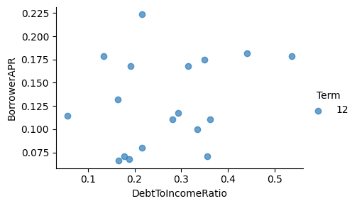

```python
g = sb.FacetGrid(data = grt_15k, hue = 'Term',
                 palette = 'viridis_r', aspect=1.5)
g.map(sb.regplot, 'DebtToIncomeRatio', 'BorrowerAPR',
      x_jitter=0.04, fit_reg=False, color=sb.color_palette('Blues')[4],scatter_kws = {'alpha':0.7})
g.add_legend();
```

We proceed to look at the variables for the entire dataset.

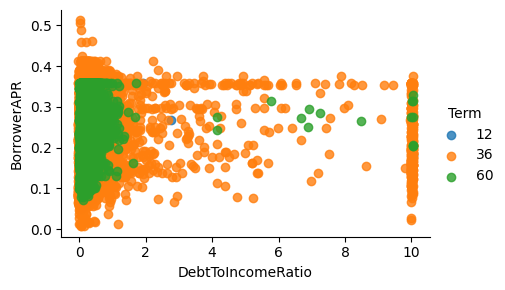

```python
g = sb.FacetGrid(data = loanDataSubset, hue = 'Term', hue_order=[12, 36, 60], aspect=1.5)
g.map(sb.regplot, 'DebtToIncomeRatio', 'BorrowerAPR',
      x_jitter=0.04, fit_reg=False)
g.add_legend();
```

12 months Term have low DebtToIncomeRatio.

We look into how LoanStatus relates to some numeric variables.

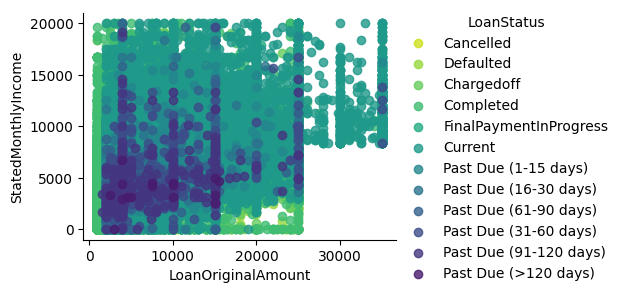

```python
plt.figure(figsize=[15, 8])
g = sb.FacetGrid(data = loanDataSubset, hue = 'LoanStatus',
                 palette = 'viridis_r', aspect=1.5)
g.map(sb.regplot, 'LoanOriginalAmount', 'StatedMonthlyIncome', x_jitter=0.04, fit_reg=False)
g.add_legend();
```

Loans listed for individuals with higher incomes appear to be moslty in a positive outcome, especially those of above \$25,000 offered for Income level above \$7,500. While generally large loans(>\$15,000) tend to have a positive outcome, loans that were either Cancelled, Defauled or Charged of were from lower Income levels, (<\$2500).

How does BorrowerAPR and Term affect LoanStatus?

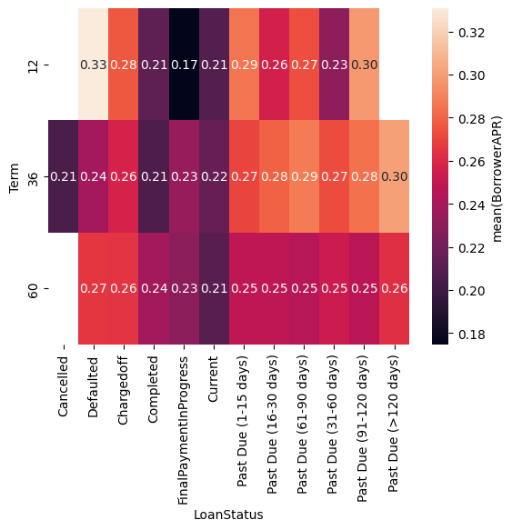

```python
meanBorrowerAPR = loanDataSubset.groupby(['LoanStatus', 'Term'])['BorrowerAPR'].mean()
meanBorrowerAPR = meanBorrowerAPR.reset_index(name = 'BorrowerAPR_avg')
meanBorrowerAPR = meanBorrowerAPR.pivot(index = 'Term', columns = 'LoanStatus',
                            values = 'BorrowerAPR_avg')
sb.heatmap(meanBorrowerAPR, annot = True, fmt = '.2f',
           cbar_kws = {'label' : 'mean(BorrowerAPR)'});
```

In the heat map above, There is a conistant pattern accross loan Term for all level of LoanStatus category, where lower BorrowerAPR are in the 3 levels; Current, Completed and FinalPaymentInProgress. Higher BorrowerAPR for all Term lenth are typically in the 3 levels Defaulted, ChargedOff or Past Due.

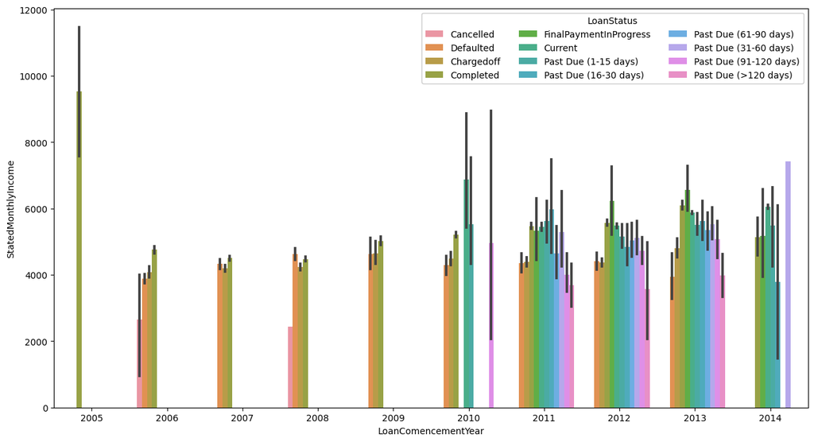

```python
plt.figure(figsize=(15,8))
ax = sb.barplot(data = loanDataSubset, x = 'LoanComencementYear', y = 'StatedMonthlyIncome', hue = 'LoanStatus')
ax.legend(loc = 0, ncol = 3, framealpha = 1, title = 'LoanStatus');
```

1. What is more interesting is, Past Due had individuals with the highest incomes for loan originating in 2014.
2. All loans from 2005 were paid back. While 2005 has the highest income, it maybe worth while investigating the error bar.
3. On average accross the years, Higher incomes correspond to Completed and current Loans, whereas Lower incomes correspoind to Past Due and Defauled loans.

Lastly, we look into how Loan amount and how it was used related to its status.

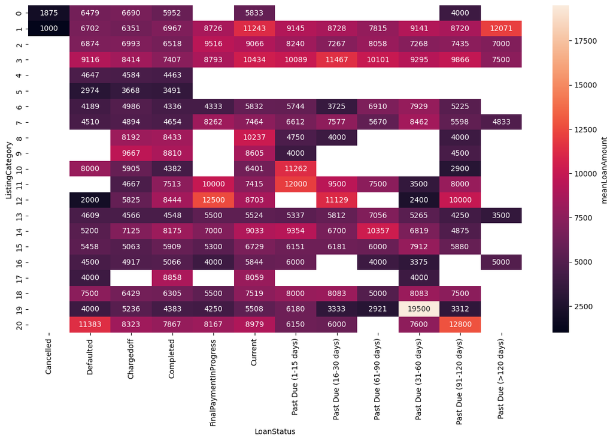

```python
plt.figure(figsize=(15,8))
meanLoanAmount = loanDataSubset.groupby(['LoanStatus', 'ListingCategory'])['LoanOriginalAmount'].mean()
meanLoanAmount = meanLoanAmount.reset_index(name = 'meanLoanAmount')
meanLoanAmount = meanLoanAmount.pivot(index = 'ListingCategory', columns = 'LoanStatus',
                            values = 'meanLoanAmount')
sb.heatmap(meanLoanAmount, annot = True, fmt = '.0f',
           cbar_kws = {'label' : 'meanLoanAmount'});
```

The amount for Business Loans(Listing category 3) was generally high accross all levels of LoanStatus, which is typical of business loans. And despite the amount, they were about equaly like to fall into any of the outcome categories. Student Loans(5) and Personal loans(4) were of the lowest amounts, and there weren't any active loans from either levels. For every level of LoanStatus There is a Debt consolidation Loan(1), this is consistant with this category being the most common ListingCategory. What is interesting is loans with least amount were the ones that were cancelled.

### Talk about some of the relationships you observed in this part of the investigation. Were there features that strengthened each other in terms of looking at your feature(s) of interest?

BorrowerAPR appear to negatively affect Loan Status, with higher BorrowerAPR tending to result in Defaulted, ChargedOff and Past Due Loans.

Income and BorrowerAPR seems to be the variables largely affecting LoanStatus.

### Were there any interesting or surprising interactions between features?

From the heatmap, we can see the interaction between the 3 numeric variables; StatedMonthlyIncome, LoanOriginalAmount and MonthlyLoanPayment. With higher incomes allowing for higher loan amouns, and higher loan amounts resulting in larger monthly repayments. Vacation had the highest mean LoanOriginalAmount and this was in the "Past due" LoanStatus. The expectation was larger loan amounts were to be spend on some form of investment.

## Conclusions

Salaries above \$20,000 were removed as there were very huge outlier in this range. BorrowerAPR has the most effect on the final LoanStatus outcome. There is a floor monthly income for loans above \$25,000. Higher income earners tended to be in the "Current" or "Complete" LoannStatus.